# Climate index - preliminary study

This notebook summarizes early results on a synthetic **extreme weather index**.

# 1 Data & package loading

First, we import the weather data. It spans the period **1980-2024** at the daily frequency.  
It comes from the [`meteostat` API](https://dev.meteostat.net/) (downloaded separately).  
We keep only 6 variables:

- **date** The date string (YYYY-MM-DD) String
- **tavg** The average air temperature in °C Float
- **tmin** The minimum air temperature in °C Float
- **tmax** The maximum air temperature in °C Float
- **prcp** The daily precipitation total in mm Float
- **wspd** The average wind speed in km/h Float

```r
library(tidyverse)     # Data wrangling
library(roll)          # Rolling functions
library(fredr)         # Saint Louis FED data
library(readxl)        # Read Excel files
library(broom)         # Neat regression output
library(tidyfit)       # Rolling regressions
library(patchwork)     # Plot layout

ewma <- function (x, ratio) {
  c(stats::filter(x * ratio, 1 - ratio, "recursive", init = x[1]))
}

impute <- function(v, n = 12){     # Imputation function
  for(j in 1:n){
    ind <- which(is.na(v))
    if(length(ind)>0){
      if(ind[1]==1){ind <- ind[-1]}
      v[ind] <- v[ind-1]
    }
  }
  return(v)
}

data <- read_excel("data.xlsx")
data <- data |>
  rename(date = time) |>
  mutate(date = as.Date(date))

url <- "https://github.com/shokru/climate/raw/main/files/us_states.xlsx"
states <- read_excel("us_states.xlsx")
```

# 2 First plots

Then, we test some standard visualizations, here focused on **Alabama** (arbitrary choice).  
They clearly show seasonal effects for temperature, maybe less so for wind speed and almost none for rainfall.

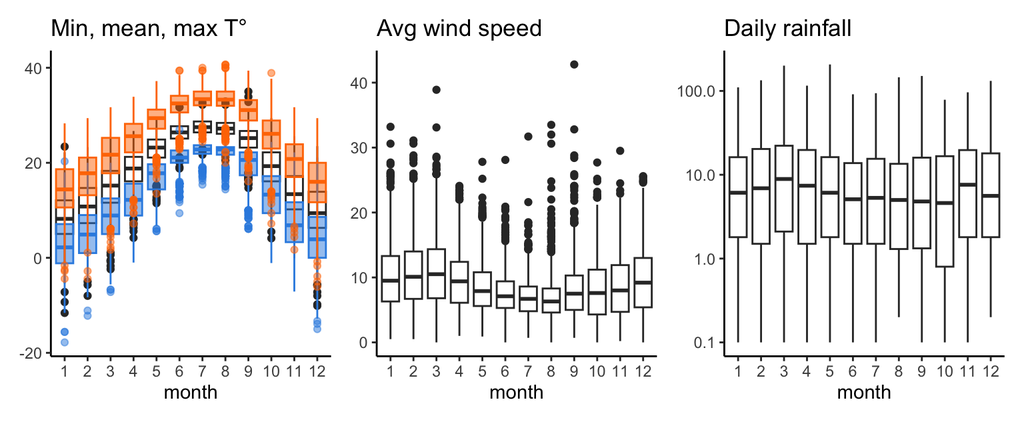

```r
g1 <- data |>
  mutate(month = month(date)) |>
  filter(state == "Alabama") |>
  ggplot() + theme_classic() +
  geom_boxplot(aes(x = as.factor(month), y = tavg)) +
  geom_boxplot(aes(x = as.factor(month), y = tmin), fill = "#338EE3", color = "#338EE3", alpha = 0.5) +
  geom_boxplot(aes(x = as.factor(month), y = tmax), fill = "#FF7800", color = "#FF7800", alpha = 0.5) +
  theme(axis.title.y = element_blank()) + ggtitle("Min, mean, max T°") + xlab("month")

g2 <- data |>
  mutate(month = month(date)) |>
  filter(state == "Alabama") |>
  ggplot() + theme_classic() +
  geom_boxplot(aes(x = as.factor(month), y = wspd)) + xlab("month") +
  theme(axis.title.y = element_blank()) + ggtitle("Avg wind speed")

g3 <- data |>
  mutate(month = month(date)) |>
  filter(state == "Alabama") |>
  ggplot() + theme_classic() +
  geom_boxplot(aes(x = as.factor(month), y = prcp)) + xlab("month") +
  theme(axis.title.y = element_blank()) + ggtitle("Daily rainfall") +
  scale_y_log10()

g1+g2+g3
```

# 3 First attempt for an extreme weather index

Next, we define thresholds that will determine what “*extreme*” means. For each state and metric, the threshold is the 2% level, meaning a scenario that occurs once every 50 days. Henceforth, the notations are as follows: $t$ is the time index and $s$ the state index.  
We focus on 4 **situations**:

- abnormaly high **maximum temperature** $T^+_{t,s}$ (very warm days);
- abnormaly low **minimum temperature** $T^-_{t,s}$ (very cold days);
- extreme **daily precipitation** $P_{t,s}$ (very rainy days);
- extreme **average wind speed** $W_{t,s}$ during the day (potential storm) - maximum speed during the day is much less reported.

The corresponding state-specific thresholds (quantiles) are written $q^+_s$, $q_s^-$, $q^P_s$ and $q_s^W$.

**NOTE**: there is a trade-off inherent to the threshold level. The more conservative it is (more extreme), the fewer the number of days with nonzero scores.

Below, we depict the thresholds for all states (when available).

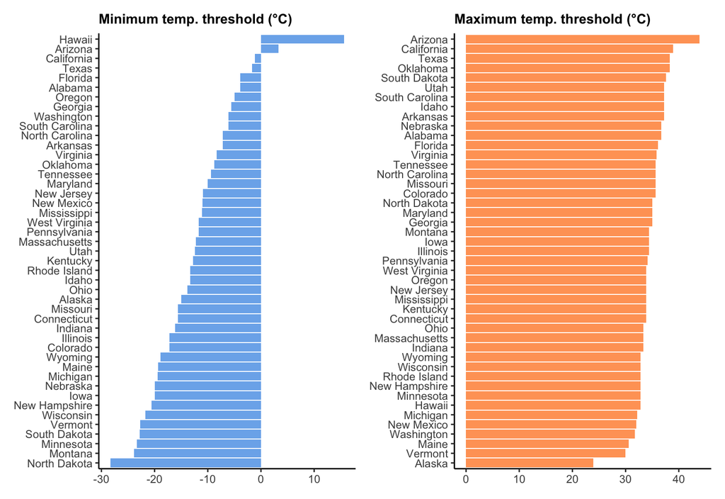

```r
thresh <- 0.02
date_thresh <- "2005-01-01"
data_thresh <- data |>
  filter(date < date_thresh) |>
  mutate(month = month(date)) |>
  group_by(state) |>
  summarise(t_low = quantile(tmin, thresh, na.rm = T),
            t_high = quantile(tmax, 1-thresh, na.rm = T),
            p_high = quantile(prcp, 1-thresh, na.rm = T),
            w_high = quantile(wspd, 1-thresh, na.rm = T))

g1 <- data_thresh |>
  ggplot(aes(x = t_low, y = reorder(state, t_low))) +
  geom_col(fill = "#338EE3", alpha = 0.7) + theme_classic() +
  theme(axis.title = element_blank(),
        title = element_text(size = 9, face = "bold")) +
  ggtitle("Minimum temp. threshold (°C)")
g2 <- data_thresh |>
  ggplot(aes(x = t_high, y = reorder(state, t_high))) +
  geom_col(fill = "#FF7800", alpha = 0.7) + theme_classic() +
  theme(axis.title = element_blank(),
        title = element_text(size = 9, face = "bold")) +
  ggtitle("Maximum temp. threshold (°C)")
g3 <- data_thresh |>
  ggplot(aes(x = p_high, y = reorder(state, p_high))) +
  geom_col(fill = "#1A4CB8", alpha = 0.7) + theme_classic() +
  theme(axis.title = element_blank(),
        title = element_text(size = 9, face = "bold")) +
  ggtitle("Maximum precip. threshold (mm)")
g4 <- data_thresh |>
  ggplot(aes(x = w_high, y = reorder(state, w_high))) +
  geom_col(fill = "#B8B9B9", alpha = 0.7) + theme_classic() +
  theme(axis.title = element_blank(),
        title = element_text(size = 9, face = "bold")) +
  ggtitle("Maximum wind speed threshold (km/h)")
g1+g2
```

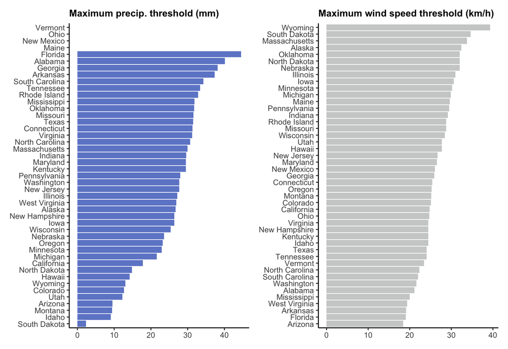

```r
g3+g4
```

```r
rm(g1, g2, g3, g4)
```

Then, based on these quantiles, we craft a metric that measures **extreme daily weather** across all states (when data is available).
The formula is the following:
$$I_t = \sum_{s=1}^{50} \text{gdp}_s\left(1_{T_{t,s}^+>q^+_s}+0.5\times 1_{T_{t,s}^-<q^-_s}+1_{W_{t,s}>q^W_s}+1_{P_{t,s}>q_s^P} \right),$$
where $\text{gdp}_s$ is the **relative weight in GDP** of state $s$ (measured in 2022). Indeed, we seek to measure the economic or financial impact, hence GDP is a relevant weighting measure. These weights sum to one. There is a 0.5 scaling factor for very low temperatures. This is to bring balance between extreme cold & hot events. Without this constant, the top 12 events occur during the winter. Perhaps because winter storms score on 3 items (cold + precipitation/snow + wind).

We also test an Exponentially Weighted Moving Average version to see if a smoother version of the index may be useful (spoiler: not so much).

Below, we plot the full series (left), as well as a zoom on the latest 63 days (right) - in 2024.

```r
min_index <- 0.00
index <- data |>
  left_join(data_thresh, by = "state") |>
  left_join(states |> select(state, GDP), by = "state") |>
  mutate(temp_up = tmax > t_high,
         temp_down = tmin < t_low,
         rain = prcp > p_high,
         wind = wspd > w_high,
  ) |>
  group_by(date) |>
  mutate(weight = GDP / sum(GDP)) |>
  summarise(index = sum(weight*(temp_up+temp_down*0.5+rain+wind), na.rm = T)) |>
  mutate(index = if_else(index==0, min_index, index),
         index_ewma = ewma(index, 0.8))
```

A snapshot at extreme events. All of them

```r
index |> filter(index > 0.5)
```

| date | index | index_ewma |
| --- | --- | --- |
| 1982-01-04 | 0.5910539 | 0.4897206 |
| 1983-12-24 | 0.7941718 | 0.6659960 |
| 1985-01-20 | 0.5764868 | 0.4889051 |
| 1988-07-17 | 0.5341026 | 0.5149721 |
| 1996-01-27 | 0.5266980 | 0.4554958 |
| 2006-07-17 | 0.5602218 | 0.4730087 |
| 2022-12-23 | 0.6582060 | 0.5715595 |

Some plots.

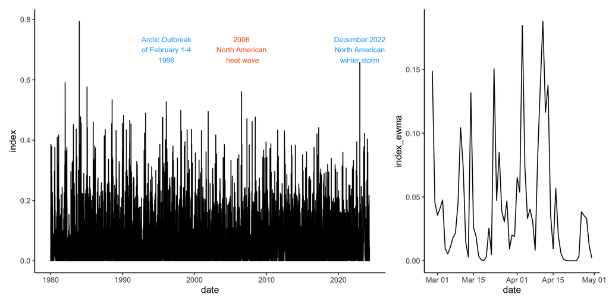

```r
(index |>
    ggplot(aes(x = date, y = index)) + geom_line() + theme_classic() +
   annotate("text", label = "December 2022\nNorth American\nwinter storm", color = "#01AAFF",
            x = as.Date("2022-12-23"), y = 0.7, size = 3) +
   annotate("text", label = "Arctic Outbreak\nof February 1-4\n1996", color = "#01AAFF",
            x = as.Date("1996-02-04"), y = 0.7, size = 3) +
   annotate("text", label = "2006\nNorth American\n heat wave", color = "#FF5D01",
            x = as.Date("2006-07-17"), y = 0.7, size = 3)
   ) +
  (index |>
     tail(63) |>
     ggplot(aes(x = date, y = index_ewma)) + geom_line() + theme_classic()) +
  plot_layout(widths = c(6, 3))
```

# 4 Link with financial returns

We first fetch the data. Two indices: [**SPY**](https://finance.yahoo.com/quote/SPY) for equities and [**IUAG.L**](https://finance.yahoo.com/quote/IUAG.L/) for bonds.  
Because of the availability of the latter, the analysis only starts in 2011.

```r
library(quantmod)
tickers <- c("SPY", "IUAG.L")
# Tickers: Apple, Boeing, Citigroup, Pfizer, Walmart, Exxon
# Others: , "F", "DIS", "GE", "CVX", "MSFT", "GS")
min_date <- "2000-01-01"                      # Starting date
max_date <- "2024-05-27"                      # Ending date
prices <- getSymbols(tickers, src = 'yahoo',  # The data comes from Yahoo Finance
                     from = min_date,         # Start date
                     to = max_date,           # End date
                     auto.assign = TRUE,
                     warnings = FALSE) %>%
  map(~Ad(get(.))) %>%                        # Retrieving the data
  reduce(merge) %>%                           # Merge in one dataframe
  `colnames<-`(tickers) %>%                   # Set the column names
  #to.monthly(indexAt = "lastof", OHLC = FALSE) %>%      # Convert to monthly
  data.frame(date = index(.)) %>%             # Convert the index to a date
  remove_rownames() %>%                       # Remove index => converted into row names
  mutate_all(impute) |>                       # Impute
  na.omit()                                   # Remove missing points

tail(prices,7)                                # Have a look at the result!
```

|  | SPY | IUAG.L | date |
| --- | --- | --- | --- |
| 6193 | 511.29 | 92.30 | 2024-05-03 |
| 6194 | 516.57 | 92.30 | 2024-05-06 |
| 6195 | 517.14 | 92.62 | 2024-05-07 |
| 6196 | 517.19 | 92.40 | 2024-05-08 |
| 6197 | 520.17 | 92.35 | 2024-05-09 |
| 6198 | 520.84 | 92.35 | 2024-05-10 |
| 6199 | 520.89 | 92.43 | 2024-05-13 |

```r
returns <- prices %>%                                    # Start from prices
  pivot_longer(-date, names_to = "Asset",
               values_to = "Price") %>%                  # Put the data in 'tidy' format
  group_by(Asset) %>%                                    # Group the rows by asset to compute returns
  mutate(return_01 = lead(Price) / Price - 1,            # Compute the returns
         return_05 = lead(Price, 5) / Price - 1,
         return_21 = lead(Price, 21) / Price - 1) %>%
  ungroup() |>
  pivot_longer(Price:return_21, names_to = "var", values_to = "value")

rm(SPY, IUAG.L)
```

A few full-sample regression results below.

```r
data_reg <- returns |>
  left_join(index, by = "date") |>
  mutate(d_index = index - lag(index),
         index_2 = index^2)

data_reg %>% filter(var != "Price") %>% group_by(Asset, var) %>%
  do(tidy(lm(value ~ index, data = .))) |> filter(term == "index")
```

| Asset | var | term | estimate | std.error | statistic | p.value |
| --- | --- | --- | --- | --- | --- | --- |
| IUAG.L | return_01 | index | 0.0007016618 | 0.0006786216 | 1.0339516 | 0.301235862 |
| IUAG.L | return_05 | index | -0.0001568878 | 0.0015271668 | -0.1027313 | 0.918182586 |
| IUAG.L | return_21 | index | -0.0079251470 | 0.0030676906 | -2.5834245 | 0.009826003 |
| SPY | return_01 | index | 0.0005224043 | 0.0024899316 | 0.2098067 | 0.833831714 |
| SPY | return_05 | index | 0.0064315276 | 0.0051623372 | 1.2458558 | 0.212907289 |
| SPY | return_21 | index | -0.0074233873 | 0.0099128846 | -0.7488625 | 0.453994581 |

The results are not very impressive, especially for equities. Only one case seems promising: 1m forward bond returns.  
Let’s move to dynamic **rolling regressions**. We take 21 day samples.

```r
# bind_cols(data_reg,
#           roll_lm(x = data_reg$index,
#                   y = data_reg$SPY,
#                   width = 21,
#                   intercept = TRUE)$coefficients
# ) |>
#   ggplot(aes(x = date, y = x1)) + geom_line() + theme_classic()
```

```r
roll_reg <- data_reg |>
  filter(var != "Price") |>
  group_by(Asset, var) %>%
  regress(value ~ index,
          m("lm"),# vcov. = "HAC"),
          .cv = "sliding_index",
          .cv_args = list(lookback = days(21), step = 5, index = "date"),
          .force_cv = TRUE,
          .return_slices = TRUE)
```

To show relevance, we plot $t$-statistics, with 5% significance levels.

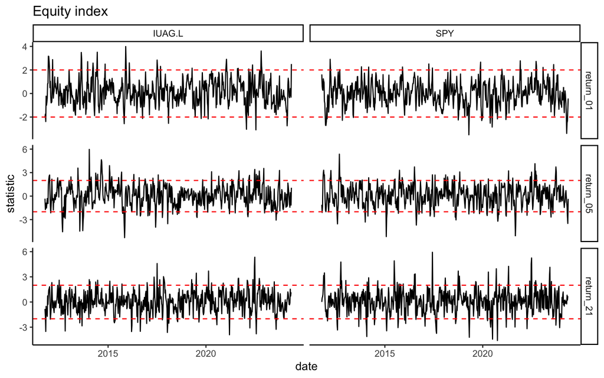

```r
df_beta <- coef(roll_reg)
df_beta <- df_beta %>%
  unnest(model_info) %>%
  mutate(upper = estimate + 2 * std.error, lower = estimate - 2 * std.error)

df_beta |>
  mutate(date = as.Date(slice_id)) %>%
  filter(term == "index") |>
  ggplot(aes(x = date, y = statistic)) + geom_line() + theme_classic() +
  geom_hline(yintercept = 2, color = "red", linetype = 2) +
  geom_hline(yintercept = -2, color = "red", linetype = 2) + ggtitle("Equity index") +
  facet_grid(rows = vars(var), cols = vars(Asset), scales = "free")
```

```r
# df_beta |>
#   mutate(date = as.Date(slice_id)) %>%
#   filter(term == "index") |>
#   arrange(date) |>
#   tail(200) |>
#   ggplot(aes(x = date, y = statistic)) + geom_line() + theme_classic() +
#   geom_hline(yintercept = 2, color = "red", linetype = 2) +
#   geom_hline(yintercept = -2, color = "red", linetype = 2) + ggtitle("Equity index") +
#   facet_grid(rows = vars(var), cols = vars(Asset), scales = "free")
```

Results are most of the time *non*-significant (as above in the full sample model).  
What about the differentiated index $\Delta I_t = I_t-I_{t-1}$?

```r
roll_reg_d <- data_reg |>
  filter(var != "Price") |>
  group_by(Asset, var) %>%
  regress(value ~ d_index,
          m("lm"),# vcov. = "HAC"),
          .cv = "sliding_index",
          .cv_args = list(lookback = days(21), step = 5, index = "date"),
          .force_cv = TRUE,
          .return_slices = TRUE)
df_beta_d <- coef(roll_reg_d)
df_beta_d <- df_beta_d %>%
  unnest(model_info) %>%
  mutate(upper = estimate + 2 * std.error, lower = estimate - 2 * std.error)
```

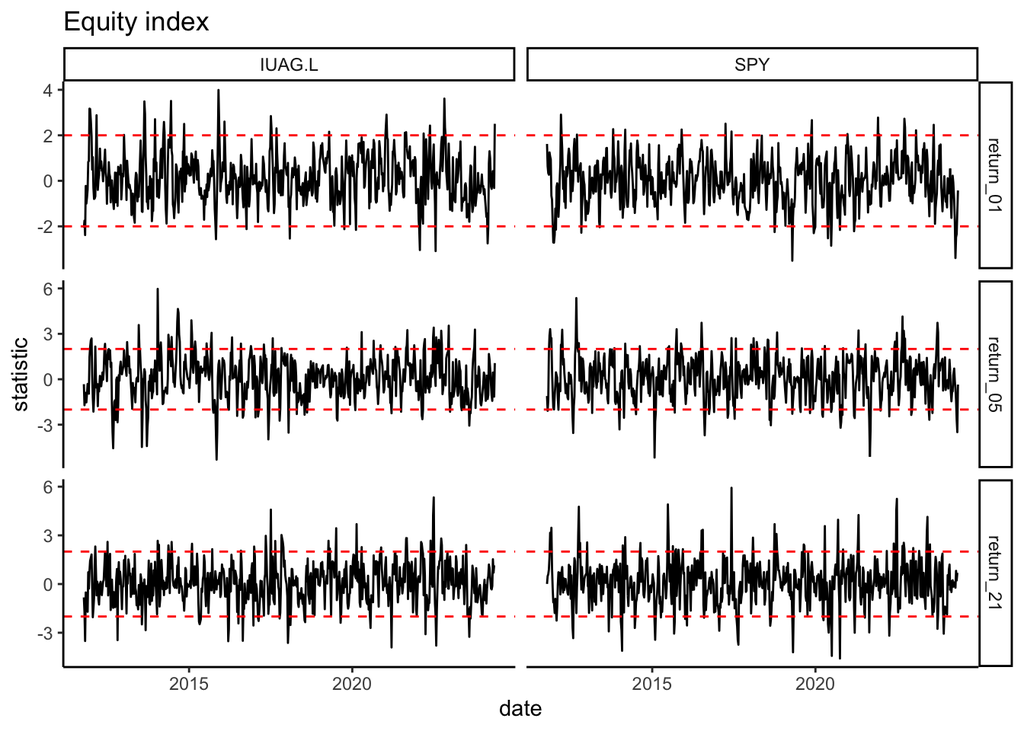

```r
df_beta |>
  mutate(date = as.Date(slice_id)) %>%
  filter(term == "index") |>
  ggplot(aes(x = date, y = statistic)) + geom_line() + theme_classic() +
  geom_hline(yintercept = 2, color = "red", linetype = 2) +
  geom_hline(yintercept = -2, color = "red", linetype = 2) + ggtitle("Equity index") +
  facet_grid(rows = vars(var), cols = vars(Asset), scales = "free")
```

Again, no pronounced (long) **pocket of predictability** - but maybe local patterns.